# Project: Investigate a Dataset about medical appointments in Brazil and exploring which characteristics determine wether a patients shows up at a certain appointment or not.

- Introduction
- Data Wrangling
- Exploratory Data Analysis
- Conclusions

## Introduction

For this report I chose the "No-show appointments" dataset which is a collection of information about 100k medical appointments. The dataset focuses on the questions, wether a patient showed up for his/her appointment and provides further patient-related information (such as gender, age, patients neighborhood, deseaes, etc..) and appointment-related informationen (scheduled day, appointment day, etc..).

The investigation of the dataset shall answer the following questions:

1. In which way does the patients age and sex have an impact for the patient to show up?
2. How does the enrollment in the Brasilian welfare program have an impact?
3. Do some sort of deseas lead the patient to show up more than the other?
4. Is a SMS helpfull to get more people to show up at the appointment?

```python
import numpy as np
import pandas as pd
import matplotlib.pyplot as plt
import seaborn as sns

% matplotlib inline
```

## Data Wrangling

Before working with the dataset described above, it was downloaded from the link provided in Part 2 "Project Details", converted into a .csv file and afterwards imported in this notebook as `input.csv`.

To begin with, lets load the csv file into a pandas dataframe-object and get some information about the dataframes structure.

### General Properties

```python
df = pd.read_csv('input.csv')
df.shape
```

```
(110527, 14)
```

As seen above, the dataframe consists of 110,527 rows, indicating appointments, and 14 coloumns. Before we go on to examine the structure of the dataframe, we first want to see, if there are any duplicates and if so, remove them.

```python
df.duplicated().value_counts()
```

```
False    110527
dtype: int64
```

This dataframe has no duplicates and so we don't have to worry about them. Next, let's see, what the structure looks like.

```python
df.head()
```

|  | PatientId | AppointmentID | Gender | ScheduledDay | AppointmentDay | Age | Neighbourhood | Scholarship | Hipertension | Diabetes | Alcoholism | Handcap | SMS_received | No-show |
| --- | --- | --- | --- | --- | --- | --- | --- | --- | --- | --- | --- | --- | --- | --- |
| 0 | 2.987250e+13 | 5642903 | F | 2016-04-29T18:38:08Z | 2016-04-29T00:00:00Z | 62 | JARDIM DA PENHA | 0 | 1 | 0 | 0 | 0 | 0 | No |
| 1 | 5.589978e+14 | 5642503 | M | 2016-04-29T16:08:27Z | 2016-04-29T00:00:00Z | 56 | JARDIM DA PENHA | 0 | 0 | 0 | 0 | 0 | 0 | No |
| 2 | 4.262962e+12 | 5642549 | F | 2016-04-29T16:19:04Z | 2016-04-29T00:00:00Z | 62 | MATA DA PRAIA | 0 | 0 | 0 | 0 | 0 | 0 | No |
| 3 | 8.679512e+11 | 5642828 | F | 2016-04-29T17:29:31Z | 2016-04-29T00:00:00Z | 8 | PONTAL DE CAMBURI | 0 | 0 | 0 | 0 | 0 | 0 | No |
| 4 | 8.841186e+12 | 5642494 | F | 2016-04-29T16:07:23Z | 2016-04-29T00:00:00Z | 56 | JARDIM DA PENHA | 0 | 1 | 1 | 0 | 0 | 0 | No |

The table above shows the first five rows of the dataframe. We can see each coloumn and the entry for each row. Let's now move on and indentiy the coloumns, that are not needed for answering the stated questions in the introduction:

1. PatientId
2. AppointmentID
3. ScheduledDay
4. AppointmentDay
5. Neighbourhood

Since those coloumns are not needed for the investagiation, the'll be droped of the dataframe. After dropping the coloumns, let's insure, that the identified coloumns are gone and that only the relevant are left.

```python
dropped_coloumns_df = df.drop(['PatientId', 'AppointmentID', 'ScheduledDay', 'AppointmentDay', 'Neighbourhood'], axis=1)
dropped_coloumns_df.shape
```

```
(110527, 9)
```

```python
dropped_coloumns_df.head()
```

|  | Gender | Age | Scholarship | Hipertension | Diabetes | Alcoholism | Handcap | SMS_received | No-show |
| --- | --- | --- | --- | --- | --- | --- | --- | --- | --- |
| 0 | F | 62 | 0 | 1 | 0 | 0 | 0 | 0 | No |
| 1 | M | 56 | 0 | 0 | 0 | 0 | 0 | 0 | No |
| 2 | F | 62 | 0 | 0 | 0 | 0 | 0 | 0 | No |
| 3 | F | 8 | 0 | 0 | 0 | 0 | 0 | 0 | No |
| 4 | F | 56 | 0 | 1 | 1 | 0 | 0 | 0 | No |

So by now, the irrelevant are dropped and the modified dataframe is stored in a seperate variable for later use. The structure of it looks as follows

```python
dropped_coloumns_df.info()
```

```
<class 'pandas.core.frame.DataFrame'>
RangeIndex: 110527 entries, 0 to 110526
Data columns (total 9 columns):
Gender          110527 non-null object
Age             110527 non-null int64
Scholarship     110527 non-null int64
Hipertension    110527 non-null int64
Diabetes        110527 non-null int64
Alcoholism      110527 non-null int64
Handcap         110527 non-null int64
SMS_received    110527 non-null int64
No-show         110527 non-null object
dtypes: int64(7), object(2)
memory usage: 7.6+ MB
```

Now, we have to check, if the coloumn `Gender` has only `F` and `M` as distinct values.

```python
dropped_coloumns_df['Gender'].value_counts()
```

```
F    71840
M    38687
Name: Gender, dtype: int64
```

As you can see, `Gender` has only two values representing female and male, so we don't have inconsistency regarding wrong or case-insensitiv value. We check the `No-show` coloumn the same way we did check the `Gender` coloumn.

```python
dropped_coloumns_df['No-show'].value_counts()
```

```
No     88208
Yes    22319
Name: No-show, dtype: int64
```

Here we have also two distinct values for that and also can move on.

Next, let's see, if the age values are valid.

```python
age = dropped_coloumns_df[dropped_coloumns_df['Age'] < 0]
age
```

|  | Gender | Age | Scholarship | Hipertension | Diabetes | Alcoholism | Handcap | SMS_received | No-show |
| --- | --- | --- | --- | --- | --- | --- | --- | --- | --- |
| 99832 | F | -1 | 0 | 0 | 0 | 0 | 0 | 0 | No |

It can bee seen, that there is one dataset, that has a patient with the age -1. According to the dataset description at https://www.kaggle.com/joniarroba/noshowappointments/home, the age coloumn is representing the age of the patient. Although no comments are made regarding the interpretation of the age, for this investigation it is assumed that the age of -1 is invalid and must be dropped while cleaning the dataset. This makes sense, since a human being with a negativ age could be interpreted as a unborn child, still means, that the carrying mother would be the actual patient and so this dataset can't be concidered valid.

For the other integers based coloumns, let's check if they consist only of the values 1 (means true) or 0 (means false).

```python
dropped_coloumns_df['Scholarship'].value_counts()
```

```
0    99666
1    10861
Name: Scholarship, dtype: int64
```

```python
dropped_coloumns_df['Hipertension'].value_counts()
```

```
0    88726
1    21801
Name: Hipertension, dtype: int64
```

```python
dropped_coloumns_df['Diabetes'].value_counts()
```

```
0    102584
1      7943
Name: Diabetes, dtype: int64
```

```python
dropped_coloumns_df['Alcoholism'].value_counts()
```

```
0    107167
1      3360
Name: Alcoholism, dtype: int64
```

```python
dropped_coloumns_df['Handcap'].value_counts()
```

```
0    108286
1      2042
2       183
3        13
4         3
Name: Handcap, dtype: int64
```

```python
dropped_coloumns_df['SMS_received'].value_counts()
```

```
0    75045
1    35482
Name: SMS_received, dtype: int64
```

So the integer based coloumns seem to be valid, but the `Handcap`coloumn looks weird. Accordiung to https://www.kaggle.com/joniarroba/noshowappointments/home the `Handcap` coloumn is supposed to be a true/false based coloumn and the `SMS_received`coloumn is eligible to have integer values higher than zero. It looks like the labe names of the coloumn got confused.

We will tackle the label naming now. Beside the confused label names for `SMS_recieved` and Handcap, we also adjust the labels `SMS_recieved` and `No-show` so that they are seperated by an underscore and that both words start with an uppercase letter. This is not really necessary for our investigation but makes it easer and follows a single convention.

### Data Cleaning

```python
dropped_coloumns_df.rename(columns={'No-show':'No_Show', 'SMS_received':'Handcap', 'Handcap':'SMS_Received'}, inplace=True)
dropped_coloumns_df.head()
```

|  | Gender | Age | Scholarship | Hipertension | Diabetes | Alcoholism | SMS_Received | Handcap | No_Show |
| --- | --- | --- | --- | --- | --- | --- | --- | --- | --- |
| 0 | F | 62 | 0 | 1 | 0 | 0 | 0 | 0 | No |
| 1 | M | 56 | 0 | 0 | 0 | 0 | 0 | 0 | No |
| 2 | F | 62 | 0 | 0 | 0 | 0 | 0 | 0 | No |
| 3 | F | 8 | 0 | 0 | 0 | 0 | 0 | 0 | No |
| 4 | F | 56 | 0 | 1 | 1 | 0 | 0 | 0 | No |

Let's check if SMS_Received and Handcap are now in the correct order.

```python
dropped_coloumns_df['SMS_Received'].value_counts()
```

```
0    108286
1      2042
2       183
3        13
4         3
Name: SMS_Received, dtype: int64
```

```python
dropped_coloumns_df['Handcap'].value_counts()
```

```
0    75045
1    35482
Name: Handcap, dtype: int64
```

Finally, we have to drop row 99,832 since it has an invalid age.

```python
dropped_coloumns_df.shape
```

```
(110527, 9)
```

```python
dropped_coloumns_df = dropped_coloumns_df[dropped_coloumns_df.Age >= 0]
dropped_coloumns_df.shape
```

```
(110526, 9)
```

Perfect! Now our dataset is clean and we are ready to start with the exploratory data analysis. But before we do that, we save the cleaned dataset first.

```python
dropped_coloumns_df.to_csv('cleaned_input.csv', index=False)
```

## Exploratory Data Analysis

### In which way does the patients age and sex have an impact for the patient to show up?

In order to answer the questions, we first load the cleaned dataset and split the dataframe in two for each gender respectivly.

```python
cleaned_df = pd.read_csv('cleaned_input.csv')

df_male = cleaned_df[cleaned_df['Gender'] == 'M']
df_female = cleaned_df[cleaned_df['Gender'] == 'F']
```

```python
len(cleaned_df[cleaned_df['No_Show'] == 'No'])
```

```
88207
```

```python
len(cleaned_df[cleaned_df['No_Show'] == 'Yes'])
```

```
22319
```

Then we look at the resulting dataframes for their statistical metrics.

```python
df_male.describe()
```

|  | Age | Scholarship | Hipertension | Diabetes | Alcoholism | SMS_Received | Handcap |
| --- | --- | --- | --- | --- | --- | --- | --- |
| count | 38687.000000 | 38687.000000 | 38687.000000 | 38687.000000 | 38687.000000 | 38687.000000 | 38687.000000 |
| mean | 33.736863 | 0.051904 | 0.167033 | 0.060408 | 0.055238 | 0.027270 | 0.291571 |
| std | 24.435221 | 0.221836 | 0.373010 | 0.238244 | 0.228448 | 0.180917 | 0.454492 |
| min | 0.000000 | 0.000000 | 0.000000 | 0.000000 | 0.000000 | 0.000000 | 0.000000 |
| 25% | 10.000000 | 0.000000 | 0.000000 | 0.000000 | 0.000000 | 0.000000 | 0.000000 |
| 50% | 33.000000 | 0.000000 | 0.000000 | 0.000000 | 0.000000 | 0.000000 | 0.000000 |
| 75% | 54.000000 | 0.000000 | 0.000000 | 0.000000 | 0.000000 | 0.000000 | 1.000000 |
| max | 100.000000 | 1.000000 | 1.000000 | 1.000000 | 1.000000 | 4.000000 | 1.000000 |

```python
df_female.describe()
```

|  | Age | Scholarship | Hipertension | Diabetes | Alcoholism | SMS_Received | Handcap |
| --- | --- | --- | --- | --- | --- | --- | --- |
| count | 71839.000000 | 71839.000000 | 71839.000000 | 71839.000000 | 71839.000000 | 71839.000000 | 71839.000000 |
| mean | 38.894542 | 0.123234 | 0.213519 | 0.078036 | 0.017024 | 0.019544 | 0.336892 |
| std | 22.154889 | 0.328708 | 0.409794 | 0.268229 | 0.129362 | 0.150010 | 0.472651 |
| min | 0.000000 | 0.000000 | 0.000000 | 0.000000 | 0.000000 | 0.000000 | 0.000000 |
| 25% | 21.000000 | 0.000000 | 0.000000 | 0.000000 | 0.000000 | 0.000000 | 0.000000 |
| 50% | 39.000000 | 0.000000 | 0.000000 | 0.000000 | 0.000000 | 0.000000 | 0.000000 |
| 75% | 56.000000 | 0.000000 | 0.000000 | 0.000000 | 0.000000 | 0.000000 | 1.000000 |
| max | 115.000000 | 1.000000 | 1.000000 | 1.000000 | 1.000000 | 4.000000 | 1.000000 |

With the distribution values min, 25%, 50%, 75% and max, we are able to devide the patients into age-related group, called stage, and add that stage as a column.

```python
# age grpoups males
bin_edges_male = [-0.000001, 10.000000,33.000000,54.000000, 100.000000]

# age grpoups females
bin_edges_female = [-0.000001, 21.000000,39.000000,56.000000, 115.000000]

# group names
bin_names = ['Youth', 'Early Adulthood', 'Late Adulthood', 'Elderly']

# Creates stage column
df_male['Stage'] = pd.cut(df_male['Age'], bin_edges_male, labels=bin_names)
# Creates stage column
df_female['Stage'] = pd.cut(df_female['Age'], bin_edges_female, labels=bin_names)
```

Now we are calculating the ratio of patients showing up for both gender and each age stage.

```python
male_total_number_youth = len(df_male[(df_male['Stage'] == 'Youth')])
male_total_number_early_adulthood = len(df_male[(df_male['Stage'] == 'Early Adulthood')])
male_total_number_late_adulthood = len(df_male[(df_male['Stage'] == 'Late Adulthood')])
male_total_number_elderly = len(df_male[(df_male['Stage'] == 'Elderly')])

female_total_number_youth = len(df_female[(df_female['Stage'] == 'Youth')])
female_total_number_early_adulthood = len(df_female[(df_female['Stage'] == 'Early Adulthood')])
female_total_number_late_adulthood = len(df_female[(df_female['Stage'] == 'Late Adulthood')])
female_total_number_elderly = len(df_female[(df_female['Stage'] == 'Elderly')])

male_number_of_show_up_youth = len(df_male[(df_male['Stage'] == 'Youth') & (df_male['No_Show'] == 'No')]) / male_total_number_youth
male_number_of_show_up_early_adulthood = len(df_male[(df_male['Stage'] == 'Early Adulthood') & (df_male['No_Show'] == 'No')]) / male_total_number_early_adulthood
male_number_of_show_up_late_adulthood = len(df_male[(df_male['Stage'] == 'Late Adulthood') & (df_male['No_Show'] == 'No')]) / male_total_number_late_adulthood
male_number_of_show_up_elderly = len(df_male[(df_male['Stage'] == 'Elderly') & (df_male['No_Show'] == 'No')]) / male_total_number_elderly

female_number_of_show_up_youth = len(df_female[(df_female['Stage'] == 'Youth') & (df_female['No_Show'] == 'No')]) / female_total_number_youth
female_number_of_show_up_early_adulthood = len(df_female[(df_female['Stage'] == 'Early Adulthood') & (df_female['No_Show'] == 'No')]) / female_total_number_early_adulthood
female_number_of_show_up_late_adulthood = len(df_female[(df_female['Stage'] == 'Late Adulthood') & (df_female['No_Show'] == 'No')]) / female_total_number_late_adulthood
female_number_of_show_up_elderly = len(df_female[(df_female['Stage'] == 'Elderly') & (df_female['No_Show'] == 'No')]) / female_total_number_elderly
```

And finally we plot the result.

[figure not shown]

```python
df_stage_sex = pd.DataFrame({'Sex': ['Male', 'Female'],
                              'Youth':  [male_number_of_show_up_youth, female_number_of_show_up_youth],
                              'Early Adulthood': [male_number_of_show_up_early_adulthood, female_number_of_show_up_early_adulthood],
                              'Late Adulthood': [male_number_of_show_up_late_adulthood, female_number_of_show_up_late_adulthood],
                              'Elderly': [male_number_of_show_up_elderly, female_number_of_show_up_elderly]})
df_stage_sex.set_index('Sex')
ax_stage_sex = df_stage_sex.plot(x='Sex', y=["Youth", "Early Adulthood", "Late Adulthood", "Elderly"], kind="bar", figsize=(10, 4))
ax_stage_sex.set_ylabel('Number of patients');
```

### How does the enrollment in the Brasilian welfare program have an impact?

Let's load the cleaned file first again, to answer the question.

```python
cleaned_df = pd.read_csv('cleaned_input.csv')
```

Next we get the numbers for showing up/not showing up at the appointment for patients enrolled in the wellfare program

```python
part_of_scholarship_and_met_appointment = len(cleaned_df[(cleaned_df.Scholarship == 1) & (cleaned_df.No_Show == 'No')])
part_of_scholarship_and_not_met_appointment = len(cleaned_df[(cleaned_df.Scholarship == 1) & (cleaned_df.No_Show == 'Yes')])
```

And do the same for those patients, that do not participate in the program

```python
not_part_of_scholarship_and_met_appointment = len(cleaned_df[(cleaned_df.Scholarship == 0) & (cleaned_df.No_Show == 'No')])
not_part_of_scholarship_and_not_met_appointment = len(cleaned_df[(cleaned_df.Scholarship == 0) & (cleaned_df.No_Show == 'Yes')])
```

Finally we'll plot the ratios in two pie charts.

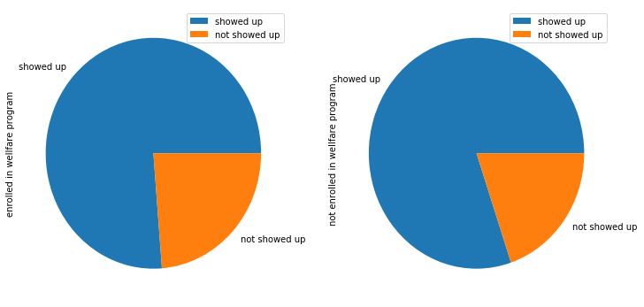

```python
df_wellfare = pd.DataFrame({'enrolled in wellfare program': [part_of_scholarship_and_met_appointment, part_of_scholarship_and_not_met_appointment],
                   'not enrolled in wellfare program': [not_part_of_scholarship_and_met_appointment, not_part_of_scholarship_and_not_met_appointment]},
                  index=['showed up', 'not showed up'])
df_wellfare.plot.pie(subplots=True, figsize=(12, 6));
```

For our conclusion later, we also take the total amount of people participating in the wellfare program in consideration.

```python
len(cleaned_df[(cleaned_df.Scholarship == 1)])
```

```
10861
```

### Do some sort of deseas lead the patient to show up more than the other?

As we've done before, we load the cleaned input file first.

```python
cleaned_df = pd.read_csv('cleaned_input.csv')
```

Next step is to calculate the number of patients that suffer from the given deseas, the number of the ones that showed up and of course the number of those who didn't.

```python
df_patients_with_hipertension = cleaned_df[cleaned_df.Hipertension == 1]
df_patients_with_diabetes = cleaned_df[cleaned_df.Diabetes == 1]
df_patients_with_alcoholism = cleaned_df[cleaned_df.Alcoholism == 1];

number_of_patients_with_hipertension = len(df_patients_with_hipertension)
number_of_patients_with_diabetes = len(df_patients_with_diabetes)
number_of_patients_with_alcoholism = len(df_patients_with_alcoholism)

number_of_patients_with_hipertension_show_up = len(df_patients_with_alcoholism[df_patients_with_alcoholism.No_Show == 'No'])
number_of_patients_with_diabetes_show_up = len(df_patients_with_diabetes[df_patients_with_diabetes.No_Show == 'No'])
number_of_patients_with_alcoholism_show_up = len(df_patients_with_alcoholism[df_patients_with_alcoholism.No_Show == 'No'])

number_of_patients_with_hipertension_not_show_up = number_of_patients_with_hipertension - number_of_patients_with_hipertension_show_up
number_of_patients_with_diabetes_not_show_up = number_of_patients_with_diabetes - number_of_patients_with_diabetes_show_up
number_of_patients_with_alcoholism_not_show_up = number_of_patients_with_alcoholism - number_of_patients_with_alcoholism_show_up
```

Finally, we draw the bar chart to see, how having some sort of deseas affected the number of patients showing up at appointments.

[figure not shown]

```python
df_deseas = pd.DataFrame({'Showed Up': ['Yes', 'No'],
                          'Hipertension':  [number_of_patients_with_hipertension_show_up, number_of_patients_with_hipertension_not_show_up],
                          'Diabetes': [number_of_patients_with_diabetes_show_up, number_of_patients_with_diabetes_not_show_up],
                          'Alcoholism': [number_of_patients_with_alcoholism_show_up, number_of_patients_with_alcoholism_not_show_up]})

df_deseas.set_index('Showed Up')
ax_deseas = df_deseas.plot(x='Showed Up', y=["Hipertension", "Diabetes", "Alcoholism"], kind="bar", figsize=(10, 4))
ax_deseas.set_ylabel('Number of patients')
ax_deseas.set_xlabel('Showed Up');
```

### Is a SMS helpfull to get more people to show up at the appointment?

Again, let's load the cleaned file first.

```python
cleaned_df = pd.read_csv('cleaned_input.csv')
```

Then extract the dataframes for each amount of SMS being sent.

```python
sms_received_0 = cleaned_df[cleaned_df.SMS_Received == 0]
sms_received_1 = cleaned_df[cleaned_df.SMS_Received == 1]
sms_received_2 = cleaned_df[cleaned_df.SMS_Received == 2]
sms_received_3 = cleaned_df[cleaned_df.SMS_Received == 3]
sms_received_4 = cleaned_df[cleaned_df.SMS_Received == 4]
```

Calculate the show up ratio for each dataframe.

```python
show_up_ratio_sms_0 = len(sms_received_0[sms_received_0.No_Show == 'No']) / len(sms_received_0)
show_up_ratio_sms_1 = len(sms_received_1[sms_received_1.No_Show == 'No']) / len(sms_received_1)
show_up_ratio_sms_2 = len(sms_received_2[sms_received_2.No_Show == 'No']) / len(sms_received_2)
show_up_ratio_sms_3 = len(sms_received_3[sms_received_3.No_Show == 'No']) / len(sms_received_3)
show_up_ratio_sms_4 = len(sms_received_4[sms_received_4.No_Show == 'No']) / len(sms_received_4)
```

```python
df_sms = pd.DataFrame(np.array([[show_up_ratio_sms_0], [show_up_ratio_sms_1], [show_up_ratio_sms_2], [show_up_ratio_sms_3], [show_up_ratio_sms_4]]),
                   columns=['Show up ratio'])
```

And last but not least, create the bar chart to visualize the calculated ratios.

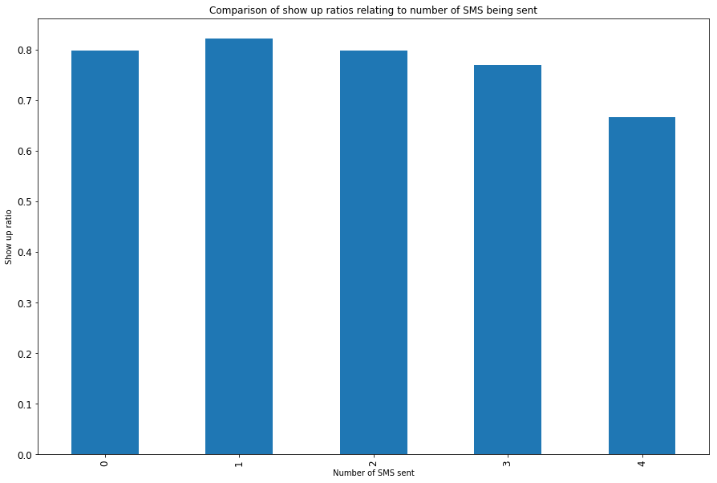

```python
ax_sms = df_sms.plot(kind='bar', title ="Comparison of show up ratios relating to number of SMS being sent", figsize=(15, 10), fontsize=12, legend=False);
ax_sms.set_xlabel('Number of SMS sent');
ax_sms.set_ylabel('Show up ratio');
```

For the sake of the interpretation of the results, we also calculate the total number of patients, that received n SMS.

```python
len(sms_received_0)
```

```
108285
```

```python
len(sms_received_1)
```

```
2042
```

```python
len(sms_received_2)
```

```
183
```

```python
len(sms_received_3)
```

```
13
```

```python
len(sms_received_4)
```

```
3
```

## Conclusions

In this section, let's discuss the results of our investigations and how they answer the asked questions in the introduction part.

Initially we asked, if there is a difference in age and gender that could show a correlation to the beahavior of patients showing up on a medical appointment or not.

The examination has shown, that, although there are slight differences (males have a higher show up rate when they are in der youth; female when they are in ther early adulthood), the distribution is more ore less the same. Both thend to have the same behavioral patterns when it comes to showing up on a medical appointment in ther mid/late stages of their lifes.

Question number two asked, if people that are enrolled in the Brasilian wellfare program show up to appointments more often than those that are not in the program.

The results show, that trend is negativ, meaning that people not in the program show up on appointments more often than people, that are part of the program, although it has to be mentioned that the difference is not significant. It must be taken into account only 10,861 patients of the investigated dataset participated in the program, which is below 10 percent of the whole number. So the behavior of a larger amount of program attendees should be observed and evaluated to get more accurate information about the effectivness of the program itself.

## Submitting your Project

> Before you submit your project, you need to create a .html or .pdf version of this notebook in the workspace here. To do that, run the code cell below. If it worked correctly, you should get a return code of 0, and you should see the generated .html file in the workspace directory (click on the orange Jupyter icon in the upper left).

> Alternatively, you can download this report as .html via the **File** > **Download as** submenu, and then manually upload it into the workspace directory by clicking on the orange Jupyter icon in the upper left, then using the Upload button.

> Once you've done this, you can submit your project by clicking on the "Submit Project" button in the lower right here. This will create and submit a zip file with this .ipynb doc and the .html or .pdf version you created. Congratulations!

```python
from subprocess import call
call(['python', '-m', 'nbconvert', 'Investigate_a_Dataset.ipynb'])
```

```
0
```